# PLASMODIUM-C2F manuscript draft v0.1

# Manuscript draft v0.1 — PLASMODIUM-C2F (M5终审后手稿打包)

> 状态：DRAFT。措辞上限 = claim_registry allowed_language（CLM08/09 CANDIDATE C2，CLM10 hypothesis）；标题禁区：no repeat-first、no dual-axes、no co-option-proven、no supply-collapse。每个实质段落末尾附 claim 追溯 tag。Figure 编号见 M5_FINAL_REVIEW §3 + storyboard §11。图版文件待图包 worker 回包后挂载（manuscript/figures/）。

## Title（候选，投稿前由用户定稿）

- T1: Genome-composition transitions propagate into Plasmodium protein-sequence space and partition regulatory architectures
- T2: Composition-driven protein-sequence turnover across Plasmodium lineages is architecturally partitioned and distinct from adaptive substitutions
- T3（弱版备用）: A composition-to-protein map of Plasmodium genome evolution with a bounded regulatory layer

## Abstract（~250 words，证据顺序 per storyboard §9）

1. 领域问题：跨物种基因组组成差异长期混淆功能解释，疟原虫 AT 极端组成与其耐药/阶段适应的关系不清 [背景]。
2. 未解缺口：组成差异中多少是机械传导、多少是功能残差，缺乏系统发育控制下的定量分解。
3. 方法原则：18 物种组成地图 + 跨层反事实 + branch-aware 位点分析 + 蛋白架构分区 + 生命周期/药物双语境映射 [M1/M2/L2/M4R]。
4. 主要发现：碱基背景解释密码子差异 84.5%、氨基酸差异 78.7%（Fig2）；组成耦合位点在 informative branches 上同向替换率 0.791（OR=2.25，LOO 7/7），落在结构化保守蛋白且与 14/14 已知耐药位点分离（Fig2–3）[CLM08]；AP2 家族 Asn 富集 OR≈35（正式集复现），但家族级 lifecycle-state 后果未确立（Fig4）[CLM09]；ART 急性/慢性分区描述成立、机制未立（Fig5）[CLM10-hypothesis]。
5. 功能闭环：单基因座实证（GCN5 poly-Asn repeat，外部阳性对照）+ 群体层耐药位点分离（Pf8）[L5半]。
6. 意义：长期组成演化限定短期应激响应空间；co-option 与 ART-MOA 仍为 hypothesis，需扰动实验裁决 [L6待]。

## Results

### Fig1 独立组成转换（M1；CLM01）

- 18 物种 genome GC 18.2%（Pgaboni）→52.3%（Tg 外群）；Laverania+avian 低、vivax+piroplasm 高两组独立对照（grade A）；7/7 LOO 保留梯度；N%/contig 非混杂（|r|<0.4）。
- 失败/边界：SP009/010 无 CDS（16 物种下游）；ovale 降级；mito/api 缺失为组装收录非生物学。

### Fig2 传导 + branch-aware 桥（M2 + D1/D3；CLM02/03/08）

- GC3 解释密码子 chi2 偏离中位 84.5%（284/288 q<0.05，效应碎片化）；CLR~genome_gc 中位 R² 78.7%（14/20 斜率显著=背景本身）；7 solid + L provisional；13 robust GC-coupled AA。
- Branch-aware：informative branches 总体 0.583；coupled 0.791 vs uncoupled 0.628（Fisher OR=2.25，p=9.5e-10）；multi-nt 0.667 > 1-nt 0.546（可达性梯度）；terminal 相关保留为描述层。
- Adaptive 分离（弱版措辞）：14/14 耐药位点跨种保守、零耦合；conservation 梯度（cons=1.0 耦合 0% vs 0.5 处 9.1%）；适应性替换 Grantham 横跨全谱。不称双适应轴。

### Fig3 架构分区 + 自然实验 + 群体边界（D2b/D6/D3/Pf8；CLM08框内）

- D2b（框内限定必写）：91 harbor 基因匹配后 LCR 零超额（MW p=0.10）、Asn-贫（0.064 vs 0.119，p=3.9e-33）、domain 富集；core-181 vs 蛋白组其余的框偏差定量（length 259 vs 472 aa；Asn 0.056 vs 0.120）。结论上限：框内 churn 不依赖 repeat；框外不宣称。
- D6：T2（AP2 4/4 p=0.0625；PUF_RNA 21/27 p=0.0030）+ T3（AP2 3/4；PUF_RNA 18/25 p=0.022）组成一致；T1 注册阴性（transition polarity 过弱）；CHROM 全程 null。规则满足靠 T2+T3。
- Pf8：34/34 耐药 markers 现群体分离（如 dhfr108 ~0.95）；CNV 率 GCH1/PM2-3 0.28、MDR1 0.20。SNP-level burden deferred 明示。

## Discussion（有界）

- 主张上限：进化总原则（框内）+ 调控富集模式 + 单基因座实证 + ART 分区描述。Association 上限，无机制动词。
- 竞争解释逐条保留：length/表达/annotation 偏倚；detection 偏倚（liver）；stage 混杂残余（弱参考）；IEA 电子注释循环（L-010 已量测：curated 非IEA 层 n=10 欠定）。
- 升级/证伪条件：L-010 已回（AP2 未消失：curated 欠定，T01 维持）；家族级 perturbation 表达链（H-A 转正）；acute translation×K13 数据（H-C 转正）；D2b 框外证伪（Fig3 降级）。

## Methods（按图 pipeline + 版本 + 种子）

- 环境：~/.conda/envs/sc（pandas 2.3.3/scipy 1.11.3）+ LD_PRELOAD（D-011）；seed 20260905；MWU 一律 asymptotic（ties 组 exact 组合爆炸教训 D-037）。
- M1：k21 sketch NJ + squared-change parsimony祖先 + 7 LOO；M2：GC3 null/CLR-OLS/BH双轨/LCR双轨；L2v2：Grantham + QC + IQ-TREE ML；D1：Fitch + branch GC + Fisher；D2b：length-decile×OG-age 8层匹配；D6：mafft –auto + 预注册 pole；A：Fisher+Woolf CI+BH + logit；C：spearman + lenadj + noSchiz + BH per contrast。
- 数据：GEO（GSE75795/120448/134268/120488/225340/59099/222586/220039-Pf/151189/226632/58402）+ Zenodo（K13 scRNA 20344254；Pf8 18681980）+ EuropePMC suppl（GCN5/Mok/AP2-P/PbApiAP2/Li2024）+ Malaria Cell Atlas + PlasmoDB-71 + NCBI frozen accessions（D001–D005）。版本/sha 见 data/checksums/*.sha256 + 各 input_manifest.tsv。
- 排除项：SRA bulk raw、FASTQ、AlphaFold bulk、作者私发数据（M4R-X01、Puf1 SI 均未碰）。

## Data availability / Code availability

- 公共数据 accession 表（manuscript/tables/ 由图包生成）+ 本地复现路径（data/raw + derived + checksums）+ 环境锁（docs/manifests/environment.sc.*）。

## Claim 追溯附录（段落→claim→evidence）

- Fig1 段→CLM01→EVID-M1-001/002/003；Fig2→CLM02/03/08→EVID-M2-001/002 + EVID-M4R-D-001/002；
- Fig3→CLM08→EVID-M4R-D-002；Fig4→CLM09→EVID-M4R-A-001/002/003（含 GO 行）；
- Fig5→CLM10-H-C + CLM04→EVID-M4R-C-001；标题/摘要→不超过 CANDIDATE/hypothesis。

# Figures

## Fig1a

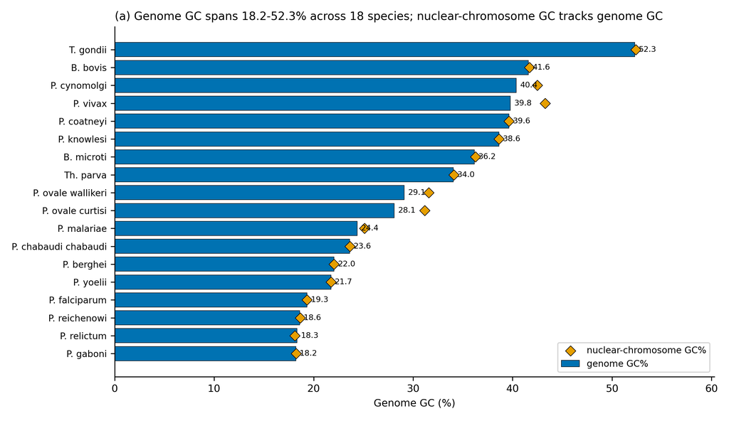

**Legend.** Figure 1 — Independent genome-composition transitions across Plasmodium (descriptive layer, CLM01/C1). One-sentence claim: Plasmodium spans a 34.1pp genome-GC gradient (18.2–52.3%, n=18 species) that is not a single AT trajectory: ancestral reconstruction and leave-one-clade-out retain the gradient 7/7, with grade-A independence (low-GC Laverania+avian vs high-GC vivax+piroplasm poles). (a) Genome GC (%) per species (n=18; frozen accessions per M1-01_composition_table.tsv; PlasmoDB-71 counterparts noted). Nuclear-chromosome GC tracks genome GC. (b) k-mer NJ species tree (M1-02_species_tree.nwk; branch lengths schematic — k-mer distances saturated) with tip genome-GC dots (blue→red) and squared-change-parsimony ancestral GC in red italics (17 internal nodes annotated from M1-02_ancestral_gc.tsv; root N0=43.6%). (c) Leave-one-clade-out: retained GC range per removed clade; gradient retained 7/7 (M1-02_leave_one_clade_out.tsv). Stats units: species (n=18; genes do not multiply species N per I3). Sensitivity: compartment split (nuclear/mito/apicoplast in source table); N%/contig artifact audit in source README. Extended pointer: full QC tables in data/derived/WP1/M1-01_composition/ and M1-02_phylogeny/. No causal/adaptive language (C1 ceiling).

## Fig1b

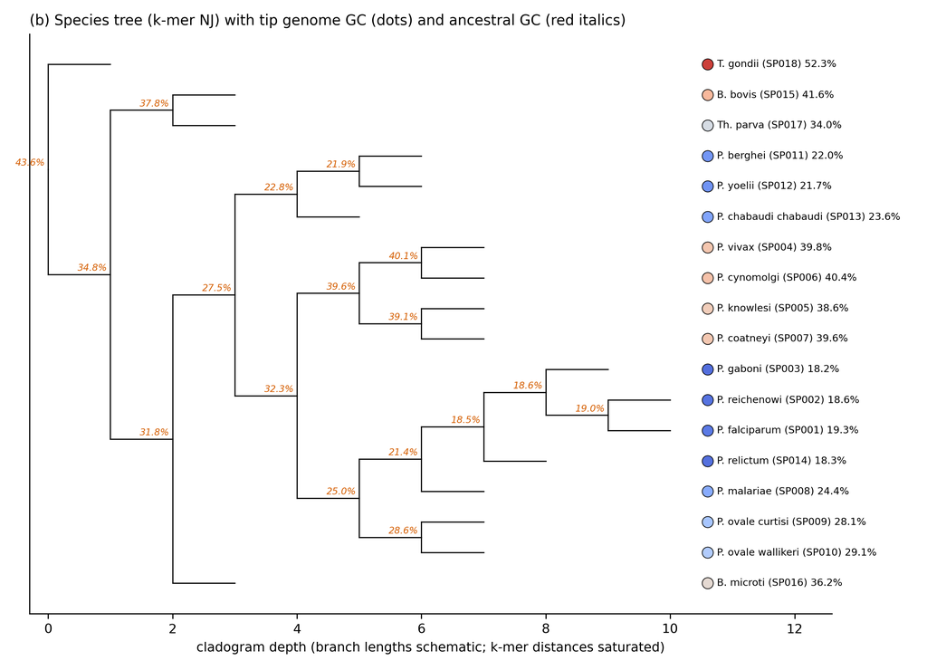

**Legend.** Figure 1 — Independent genome-composition transitions across Plasmodium (descriptive layer, CLM01/C1). One-sentence claim: Plasmodium spans a 34.1pp genome-GC gradient (18.2–52.3%, n=18 species) that is not a single AT trajectory: ancestral reconstruction and leave-one-clade-out retain the gradient 7/7, with grade-A independence (low-GC Laverania+avian vs high-GC vivax+piroplasm poles). (a) Genome GC (%) per species (n=18; frozen accessions per M1-01_composition_table.tsv; PlasmoDB-71 counterparts noted). Nuclear-chromosome GC tracks genome GC. (b) k-mer NJ species tree (M1-02_species_tree.nwk; branch lengths schematic — k-mer distances saturated) with tip genome-GC dots (blue→red) and squared-change-parsimony ancestral GC in red italics (17 internal nodes annotated from M1-02_ancestral_gc.tsv; root N0=43.6%). (c) Leave-one-clade-out: retained GC range per removed clade; gradient retained 7/7 (M1-02_leave_one_clade_out.tsv). Stats units: species (n=18; genes do not multiply species N per I3). Sensitivity: compartment split (nuclear/mito/apicoplast in source table); N%/contig artifact audit in source README. Extended pointer: full QC tables in data/derived/WP1/M1-01_composition/ and M1-02_phylogeny/. No causal/adaptive language (C1 ceiling).

## Fig1c

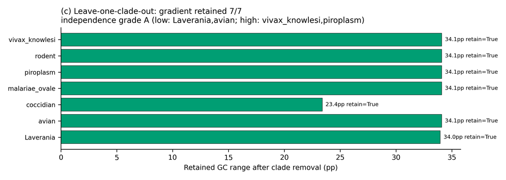

**Legend.** Figure 1 — Independent genome-composition transitions across Plasmodium (descriptive layer, CLM01/C1). One-sentence claim: Plasmodium spans a 34.1pp genome-GC gradient (18.2–52.3%, n=18 species) that is not a single AT trajectory: ancestral reconstruction and leave-one-clade-out retain the gradient 7/7, with grade-A independence (low-GC Laverania+avian vs high-GC vivax+piroplasm poles). (a) Genome GC (%) per species (n=18; frozen accessions per M1-01_composition_table.tsv; PlasmoDB-71 counterparts noted). Nuclear-chromosome GC tracks genome GC. (b) k-mer NJ species tree (M1-02_species_tree.nwk; branch lengths schematic — k-mer distances saturated) with tip genome-GC dots (blue→red) and squared-change-parsimony ancestral GC in red italics (17 internal nodes annotated from M1-02_ancestral_gc.tsv; root N0=43.6%). (c) Leave-one-clade-out: retained GC range per removed clade; gradient retained 7/7 (M1-02_leave_one_clade_out.tsv). Stats units: species (n=18; genes do not multiply species N per I3). Sensitivity: compartment split (nuclear/mito/apicoplast in source table); N%/contig artifact audit in source README. Extended pointer: full QC tables in data/derived/WP1/M1-01_composition/ and M1-02_phylogeny/. No causal/adaptive language (C1 ceiling).

## Fig2a

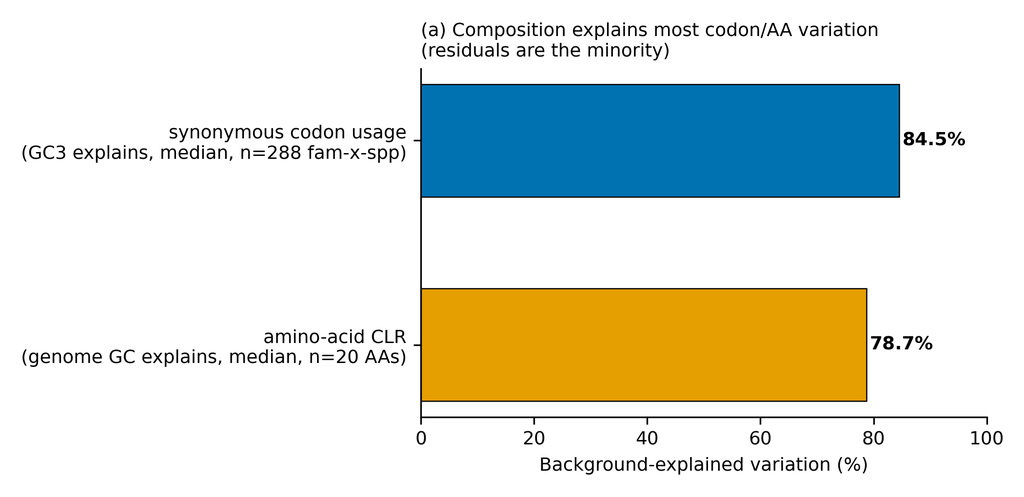

**Legend.** Figure 2 — Base composition propagates quantitatively into codon and amino-acid space; composition-coupled turnover is branch-aware and distinct from resistance sites (CLM02/CLM03/CLM08, CANDIDATE/C2). One-sentence claim: GC3 explains a median 84.5% of synonymous codon deviation and genome GC a median 78.7% of amino-acid CLR variation, yet composition-coupled sites follow branch GC/AT change far above background (fraction 0.791 vs 0.628, OR=2.25, Fisher p=9.5e-10, LOO OR range 1.71–4.35 significant 7/7), while 14/14 known resistance positions are composition-uncoupled at conserved sites. (a) Background-explained variation (median across families; codon n=288 family×species rows, AA n=20; masked track; M2-01/M2-02 background_explained tables). Residuals are the minority. (b) Branch-aware concordance forest (n_events: coupled 316, uncoupled 8821, informative 13604; 95% CI; null 0.5 dashed). Symbols differ by stratum (circle/square/triangle) in addition to color. (c) Per-site separation: 14 known resistance positions (K13 539/580, CRT 76, DHFR 51/59/108/164, DHPS 436/437/540/581, MDR1 86/184/1246; OGs in table) all uncoupled (red x); matched-background coupling rises only at lower conservation (weak reading: distinct sequence spaces, not dual adaptive axes). Stats units: parsimony sites (n=29,558; 646 ambiguous-root flagged) and branches; species are not independent replicates (branch-aware + LOO replace species-counting). Sensitivity: LCR masked/unmasked dual-track; uncertainty-site exclusion; terminal correlation retained as descriptive layer. Extended pointer: M4RD_D1_branch_substitutions.tsv (24,520 events), D1_LOO.tsv, D3 tables. Banned language respected: no dual-axes, no causal claims (association ceiling).

## Fig2b

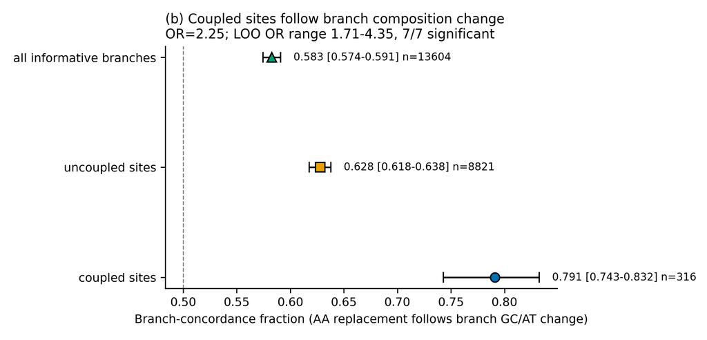

**Legend.** Figure 2 — Base composition propagates quantitatively into codon and amino-acid space; composition-coupled turnover is branch-aware and distinct from resistance sites (CLM02/CLM03/CLM08, CANDIDATE/C2). One-sentence claim: GC3 explains a median 84.5% of synonymous codon deviation and genome GC a median 78.7% of amino-acid CLR variation, yet composition-coupled sites follow branch GC/AT change far above background (fraction 0.791 vs 0.628, OR=2.25, Fisher p=9.5e-10, LOO OR range 1.71–4.35 significant 7/7), while 14/14 known resistance positions are composition-uncoupled at conserved sites. (a) Background-explained variation (median across families; codon n=288 family×species rows, AA n=20; masked track; M2-01/M2-02 background_explained tables). Residuals are the minority. (b) Branch-aware concordance forest (n_events: coupled 316, uncoupled 8821, informative 13604; 95% CI; null 0.5 dashed). Symbols differ by stratum (circle/square/triangle) in addition to color. (c) Per-site separation: 14 known resistance positions (K13 539/580, CRT 76, DHFR 51/59/108/164, DHPS 436/437/540/581, MDR1 86/184/1246; OGs in table) all uncoupled (red x); matched-background coupling rises only at lower conservation (weak reading: distinct sequence spaces, not dual adaptive axes). Stats units: parsimony sites (n=29,558; 646 ambiguous-root flagged) and branches; species are not independent replicates (branch-aware + LOO replace species-counting). Sensitivity: LCR masked/unmasked dual-track; uncertainty-site exclusion; terminal correlation retained as descriptive layer. Extended pointer: M4RD_D1_branch_substitutions.tsv (24,520 events), D1_LOO.tsv, D3 tables. Banned language respected: no dual-axes, no causal claims (association ceiling).

## Fig2c

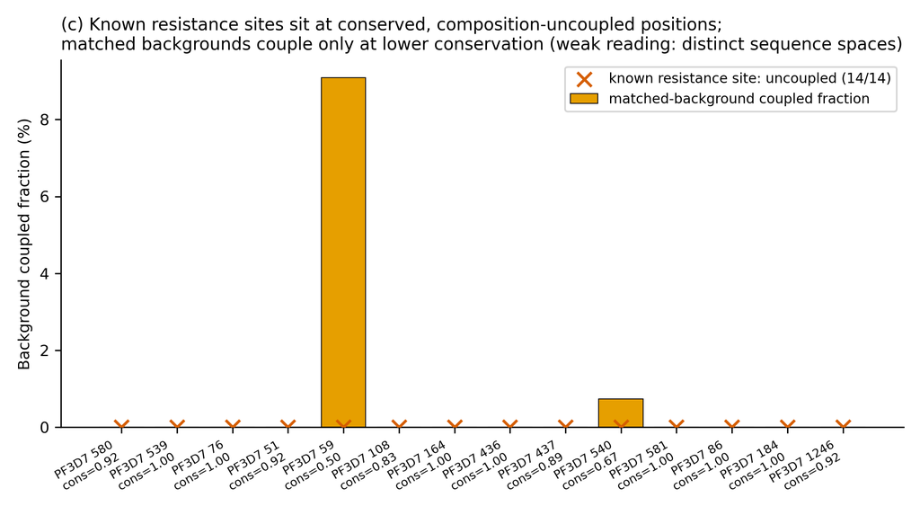

**Legend.** Figure 2 — Base composition propagates quantitatively into codon and amino-acid space; composition-coupled turnover is branch-aware and distinct from resistance sites (CLM02/CLM03/CLM08, CANDIDATE/C2). One-sentence claim: GC3 explains a median 84.5% of synonymous codon deviation and genome GC a median 78.7% of amino-acid CLR variation, yet composition-coupled sites follow branch GC/AT change far above background (fraction 0.791 vs 0.628, OR=2.25, Fisher p=9.5e-10, LOO OR range 1.71–4.35 significant 7/7), while 14/14 known resistance positions are composition-uncoupled at conserved sites. (a) Background-explained variation (median across families; codon n=288 family×species rows, AA n=20; masked track; M2-01/M2-02 background_explained tables). Residuals are the minority. (b) Branch-aware concordance forest (n_events: coupled 316, uncoupled 8821, informative 13604; 95% CI; null 0.5 dashed). Symbols differ by stratum (circle/square/triangle) in addition to color. (c) Per-site separation: 14 known resistance positions (K13 539/580, CRT 76, DHFR 51/59/108/164, DHPS 436/437/540/581, MDR1 86/184/1246; OGs in table) all uncoupled (red x); matched-background coupling rises only at lower conservation (weak reading: distinct sequence spaces, not dual adaptive axes). Stats units: parsimony sites (n=29,558; 646 ambiguous-root flagged) and branches; species are not independent replicates (branch-aware + LOO replace species-counting). Sensitivity: LCR masked/unmasked dual-track; uncertainty-site exclusion; terminal correlation retained as descriptive layer. Extended pointer: M4RD_D1_branch_substitutions.tsv (24,520 events), D1_LOO.tsv, D3 tables. Banned language respected: no dual-axes, no causal claims (association ceiling).

## Fig3a

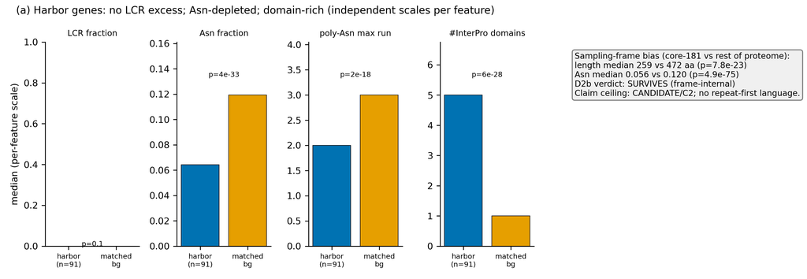

## Fig3b

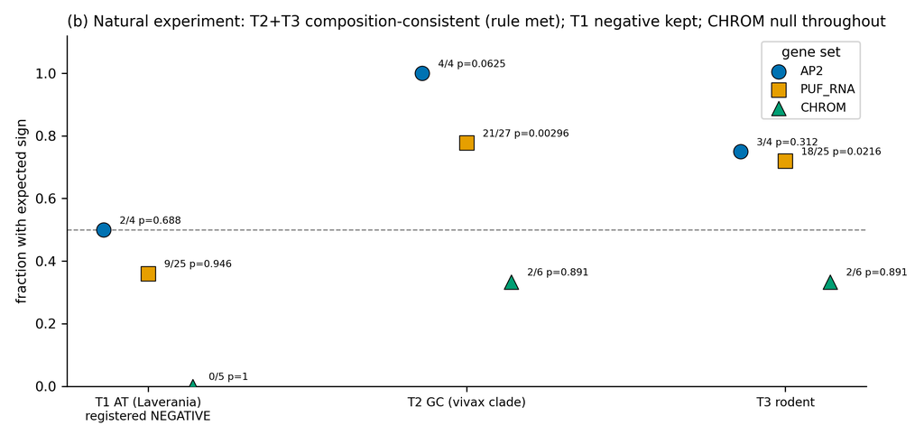

## Fig3c

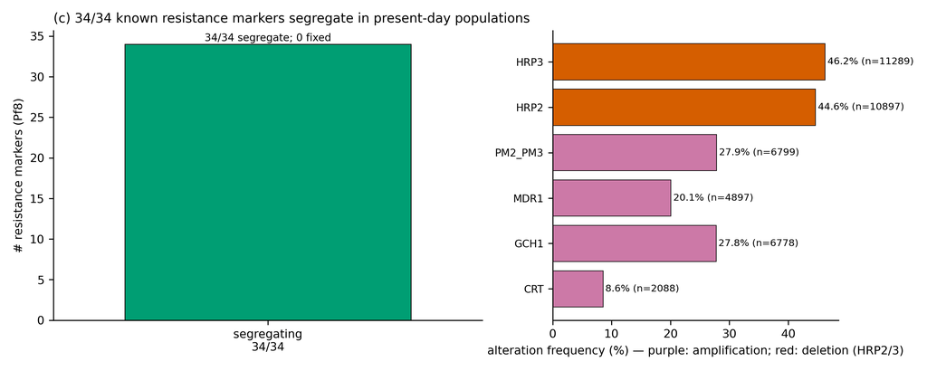

## Fig4a

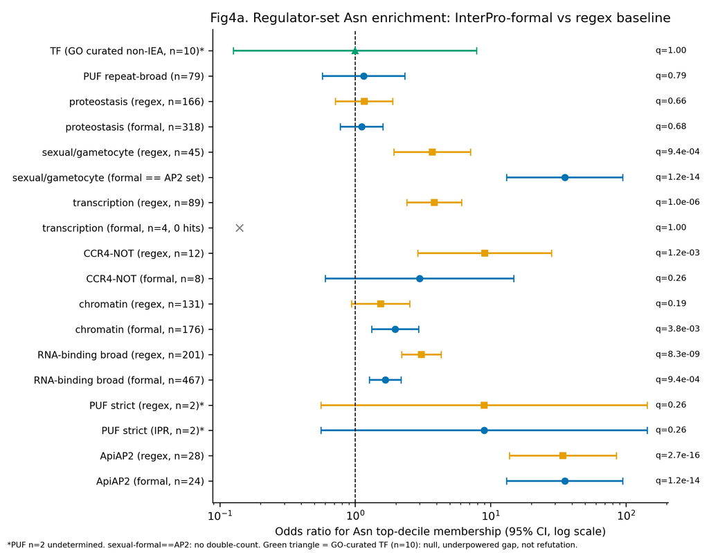

## Fig4b

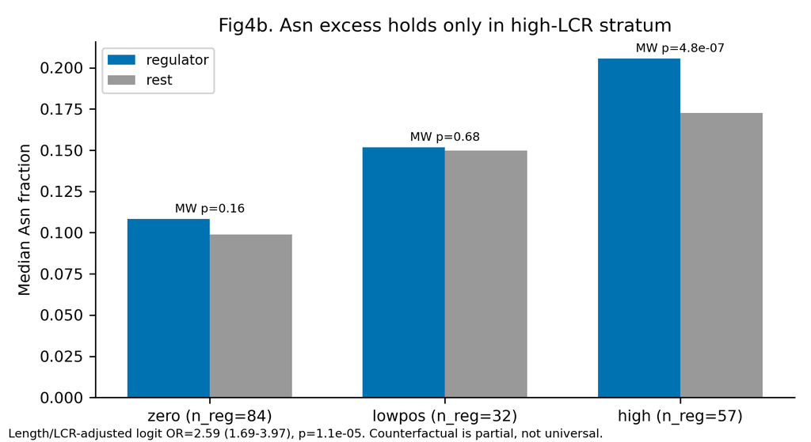

## Fig4c

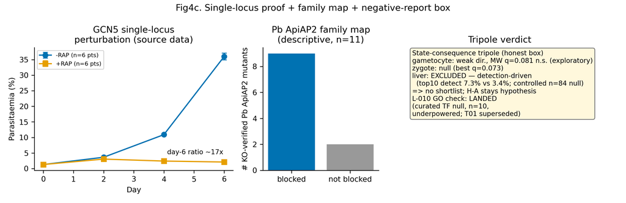